# Predictive Analytics & Forecasting - Discussion #6

## Prediction

I will create the final model and conduct predictions.

```r
air_travel_model = air_travel_train %>%
  model(
    `ETS` = ETS(pax),
    `ARIMA` = ARIMA(pax),
    `Neural Network` = NNETAR(pax)
  )

glance(air_travel_model)
```

```
## # A tibble: 3 × 11
##   .model     sigma2 log_lik   AIC  AICc   BIC      MSE     AMSE     MAE ar_roots
##   <chr>       <dbl>   <dbl> <dbl> <dbl> <dbl>    <dbl>    <dbl>   <dbl> <list>
## 1 ETS       2.76e12  -3247. 6525. 6528. 6574.  2.56e12  3.26e12 964761. <NULL>
## 2 ARIMA     2.88e12  -2840. 5693. 5693. 5712. NA       NA           NA  <cpl>
## 3 Neural N… 6.48e12     NA    NA    NA    NA  NA       NA           NA  <NULL>
## # ℹ 1 more variable: ma_roots <list>
```

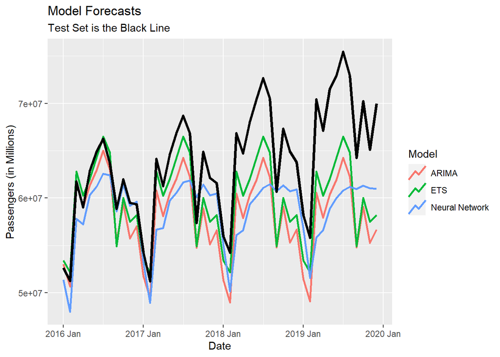

```r
air_travel_forecast = air_travel_model %>%
  forecast(air_travel_test)

# Plot
air_travel_forecast %>%
  autoplot(level = NULL, lwd = 1) +
  labs(x = "Date", y = "Passengers (in Millions)",
       title = "Model Forecasts",
       subtitle = "Test Set is the Black Line") +
  guides(color = guide_legend(title = "Model")) +
  geom_line(data = air_travel_test,
            aes(x = date, y = pax),
            lwd = 1.25)
```

```r
# Calculate Accuracy
accuracy_table = air_travel_forecast %>%
  accuracy(air_travel_test) %>%
  select(-c(.type, MASE, RMSSE)) %>%
  rename("Model" = ".model")

kable(accuracy_table,
      format = "markdown",
      caption = "Model Accuracy")
```

Model Accuracy

| Model | ME | RMSE | MAE | MPE | MAPE | ACF1 |
| --- | --- | --- | --- | --- | --- | --- |
| ARIMA | 5708345 | 6724060 | 5727725 | 8.670479 | 8.706416 | 0.8410764 |
| ETS | 4016283 | 5257934 | 4277926 | 6.013258 | 6.472202 | 0.8153483 |
| Neural Network | 5180097 | 6733198 | 5307621 | 7.703643 | 7.924927 | 0.6123514 |

With a longer time horizon than my previous discussion (6 months vs. 4 years), the forecasts do not do as well as time goes on. However, all three models perform well on the data with a MAPE of below 10%. The ETS model still performs the best, but the neural net performs better than the ARIMA model.